# Projet statistiques

BARKAOUI Meriam et MAUBLANC Albane

2023-06-16

```r
library(ggplot2)
```

```r
resultat = read.table("music-mental-health.csv", sep=",",header=TRUE)
attach(resultat)
```

# 1 - Introduction

## 1.1 Description du jeux de données:

Dans le cadre de ce projet de statistiques, nous avons sélectionné un ensemble de données portant sur la musique et la santé mentale. Ce sujet nous intéresse particulièrement et constitue une excellente opportunité d’étude.

Nos données proviennent d’un sondage réalisé via un formulaire Google. Notre ensemble de données contient plusieurs informations, notamment:  
- *Timestamp* : l’heure de soumission du formulaire.  
- *Age* : l’âge du répondant (nombre entier).  
- *Primary streaming service* : la plateforme de streaming musical préférée du répondant (chaîne de caractères).  
- *Hours per day* : le nombre d’heures d’écoute de musique par jour (nombre décimal).  
- *While working* : indique si la personne écoute de la musique en travaillant (oui/non). - *Instrumentalist* : indique si la personne joue d’un instrument de musique (oui/non). - *Composer* : indique si la personne compose de la musique (oui/non).  
- *Exploratory* : indique si la personne explore de nouveaux genres musicaux ou artistes (oui/non).  
- *Foreign languages* : indique si le répondant écoute de la musique avec des paroles dans une langue qu’il ne maîtrise pas (oui/non).  
- *BPM* : le nombre de battements par minute du genre musical préféré (nombre entier). - *Frequency [Classical], Frequency [Country], Frequency [EDM], Frequency [Folk], Frequency [Gospel], Frequency [Hip hop], Frequency [Jazz], Frequency [K pop], Frequency [Latin], Frequency [Lofi], Frequency [Metal], Frequency [Pop], Frequency [R&B], Frequency [Rap], Frequency [Rock], Frequency [Video game music]* : la fréquence à laquelle la personne écoute de la musique dans chaque genre (très fréquemment, parfois, rarement, jamais).  
- *Anxiety, Depression, Insomnia, OCD* : la personne doit s’auto-évaluer et choisir une valeur entre 0 et 10 pour déterminer le degré de présence de chaque trouble.  
- *Music effect* : l’effet de la musique sur la personne (améliore, aggrave, aucun effet).  
- *Permissions* : l’autorisation donnée par la personne pour publier ses données (I understand).

##1.2 Description des modifications de la base :

Nous avons choisi de supprimer la colonne contenant l’heure de soumission du formulaire ainsi que la colonne des permissions, car ces informations ne fournissent pas de données pertinentes pour notre étude.

```r
resultat <- resultat[, -which(names(resultat) == "Timestamp")]
resultat <- resultat[, -which(names(resultat) == "Permissions")]
```

Nous avons supprimé les individus qui n’ont pas renseigné leurs ages.

```r
resultat <- subset(resultat, !is.na(Age) & Age != "")
```

Nous avons supprimé les indidus qui qui n’ont pas renseigné le BPM.

```r
resultat <- subset(resultat, !is.na(BPM) & BPM != "")
```

```r
resultat <- subset(resultat, !is.na(Primary.streaming.service) & Primary.streaming.service != "")
```

##1.3 Description de la population étudiée :

```r
nrow(resultat)
```

```
## [1] 628
```

Après nettoyage, notre dataframe est de taille 628 et notre unité statistique est l’individu.

1.4 Description des variables d’intérêt :

**variables qualitatives**

- *Frequency [Rock]* : Représente la fréquence à laquelle la personne écoute de la musique Rock.  
  –> Il s’agit d’une variable qualitative ordonnée qui a pour valeur : (très fréquemment, parfois, rarement, jamais).
- *Primary streaming service* : Représente la plateforme de streaming musical préférée du répondant.  
  –> Il s’agit d’une variable qualitative nominale de type chaine de carctères.
- *Exploratory* : indique si la personne explore de nouveaux genres musicaux ou artistes. –> Il s’agit d’une variable qualitative nominale qui a pour valeur (oui ou non).

**variables quantitative**

- *Age* : Représente l’âge du répondant. –> Il s’agit d’une variable quantitative continue de type entier
- *Depression* : la personne doit s’auto-évaluer et choisir une valeur entre 0 et 10 pour déterminer le degré de dépression qu’elle ressent –> Il s’agit d’une variable quantitative discrète, de type entier et de valeur entre 0 et 10.
- *BPM* : le nombre de battements par minute du genre musical préféré (nombre entier).  
  –> Il s’agit d’une variable quantitative discrète, de type entier.

1.5 Liste de questions :

[output not shown]

#**2 - Analyse univariée**  
2.1 Pour chaque variable qualitative d’intérêt, faire un graphique représentatif et donner les résumés numériques adaptés : - - *Exploratory*

```r
# Compter le nombre de réponses "oui" et "non"
exploratory_counts <- table(resultat$Exploratory)
#Conversion en data frame
exploratory_counts_df <- as.data.frame(exploratory_counts)

# Renommer les colonnes du data frame
colnames(exploratory_counts_df) <- c("Reponse", "Nombre de personnes")
```

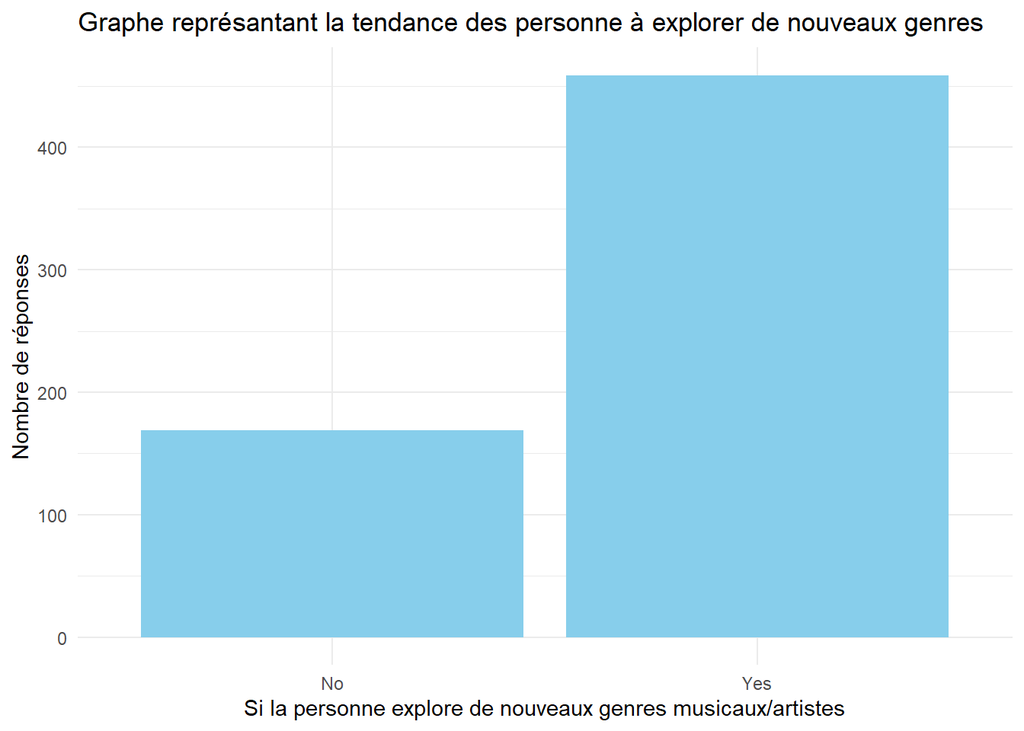

```r
# Créer le graphique à barres
bar_plot <- ggplot(data.frame(Exploratory = names(exploratory_counts_df), Count = exploratory_counts_df),
                   aes(x = exploratory_counts_df$Reponse, y = exploratory_counts_df$`Nombre de personnes`)) +
  geom_bar(stat = "identity", fill = "skyblue") +
  labs(x = "Si la personne explore de nouveaux genres musicaux/artistes", y = "Nombre de réponses", title = "Graphe représantant la tendance des personne à explorer de nouveaux genres") +
  theme_minimal()
# Définir les couleurs des barres

# Afficher le graphique
print(bar_plot)
```

- *Primary streaming service* :

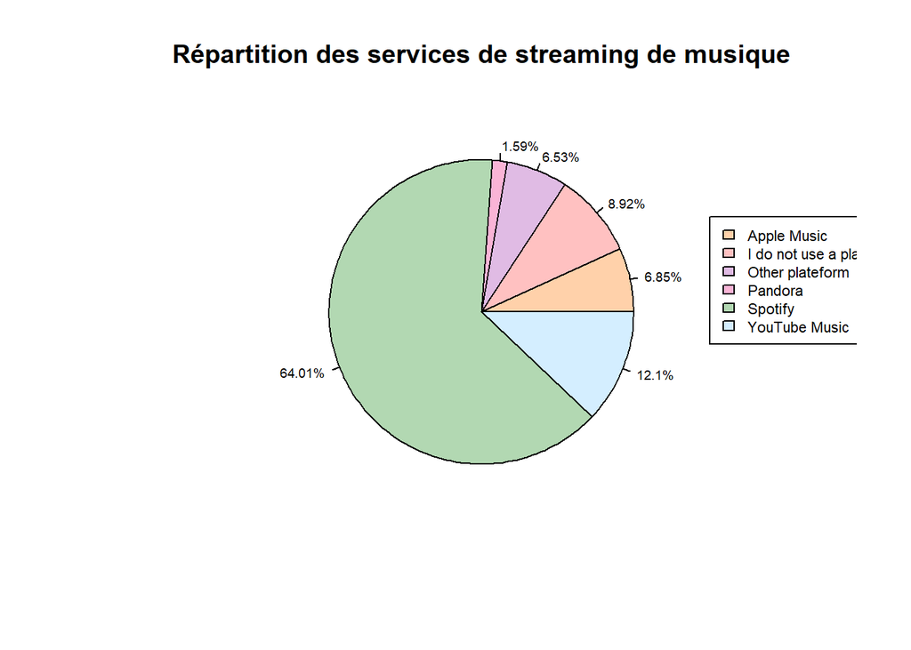

```r
streaming_counts <- table(resultat$Primary.streaming.service)
streaming_counts_df <- as.data.frame(streaming_counts)
# Calculer les pourcentages
streaming_counts_df$Percentage <- paste0(round(streaming_counts_df$Freq / sum(streaming_counts_df$Freq) * 100, 2), "%")

# Créer le graphique en camembert

pie_chart <- pie(streaming_counts, labels = streaming_counts_df$Percentage, col=c( "#FFD1AA", "#FFC1C1", "#E0BBE4", "#FAB4D6","#B2D8B2", "#D4EEFF"), main="Répartition des services de streaming de musique", cex = 0.6)
legend(1.2, .5, c("Apple Music", "I do not use a plateform." ,"Other plateform", "Pandora", "Spotify", "YouTube Music"), cex = 0.7, fill = c( "#FFD1AA", "#FFC1C1", "#E0BBE4", "#FAB4D6","#B2D8B2", "#D4EEFF"))
```

- *Frequency [Rock]* :

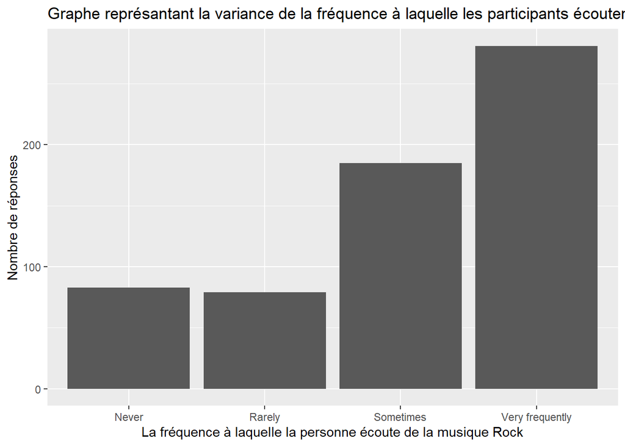

```r
frequency_rock_counts<- table(resultat$Frequency..Rock.)
frequency_rock_counts_df <- as.data.frame(frequency_rock_counts)
# Renommer les colonnes du data frame
colnames(frequency_rock_counts_df) <- c("Fréquence", "Nombre de personnes")

# Créer le graphique à barres
couleurs <- c("#AEC6CF", "#B2D8B2", "#FFD1AA", "#FFC1C1")
bar_plot_frequency <- ggplot(data.frame(Exploratory = names(frequency_rock_counts_df), Count = frequency_rock_counts_df),
                   aes(x = frequency_rock_counts_df$Fréquence, y = frequency_rock_counts_df$`Nombre de personnes`)) +
  geom_bar(stat = "identity") +
  labs(x = "La fréquence à laquelle la personne écoute de la musique Rock", y = "Nombre de réponses", title = "Graphe représantant la variance de la fréquence à laquelle les participants écoutent de la musique Rock")
# Définir les couleurs des barres

# Afficher le graphique
print(bar_plot_frequency)
```

**variables quantitative**

- *Age* : continue Regrouppement je dois argumenter (effectif + voir cahier)

```r
min(resultat$Age)
```

```
## [1] 10
```

```r
max(resultat$Age)
```

```
## [1] 89
```

```r
nombre_personnes_plus_60 <- sum(resultat$Age > 60)
print(nombre_personnes_plus_60)
```

```
## [1] 16
```

```r
max(resultat$Age)
```

```
## [1] 89
```

```r
nombre_personnes_plus_21 <- sum(resultat$Age > 0 & resultat$Age <21)
print(nombre_personnes_plus_21)
```

```
## [1] 305
```

```r
nombre_personnes_plus_50 <- sum(resultat$Age > 50)
print(nombre_personnes_plus_50)
```

```
## [1] 35
```

```r
nombre_personnes_plus_40 <- sum(resultat$Age > 40)
print(nombre_personnes_plus_40)
```

```
## [1] 57
```

```r
nombre_personnes_entre18et30 <- sum(resultat$Age > 17 & resultat$Age <31)
print(nombre_personnes_entre18et30)
```

```
## [1] 371
```

```r
nombre_personnes_entre10et18 <- sum(resultat$Age > 9 & resultat$Age <19)
print(nombre_personnes_entre10et18)
```

```
## [1] 212
```

Age minimale 10 et max 89 16 personne a plus de 60 ans regroupement [10;18[ -> enfant [18;25[ -> Jeune

```r
par(mfrow=c(1,2))
# Créer des intervalles d'âges personnalisés
intervalles <- cut(resultat$Age, breaks = c(10, 14, 18,20, 22, 26, 30, 34, 38, 42, 46, 50, Inf), right = FALSE, include.lowest = TRUE)

tableau_intervalles <- table(intervalles)
age_df<- data.frame(tableau_intervalles)
print(age_df)
```

```
##    intervalles Freq
## 1      [10,14)    9
## 2      [14,18)  128
## 3      [18,20)  132
## 4      [20,22)   77
## 5      [22,26)   97
## 6      [26,30)   54
## 7      [30,34)   40
## 8      [34,38)   24
## 9      [38,42)   14
## 10     [42,46)   10
## 11     [46,50)    7
## 12    [50,Inf]   36
```

```r
colnames(age_df) <- c("Ages", "Nombre de personnes")
age_df$Ages <- factor(age_df$Ages, levels = unique(age_df$Ages))
print(age_df$Ages)
```

```
##  [1] [10,14)  [14,18)  [18,20)  [20,22)  [22,26)  [26,30)  [30,34)  [34,38)
##  [9] [38,42)  [42,46)  [46,50)  [50,Inf]
## 12 Levels: [10,14) [14,18) [18,20) [20,22) [22,26) [26,30) [30,34) ... [50,Inf]
```

```r
#tableau_intervall
# Données d'exemplees <- c(10, 20, 15, 25, 30)
par(mfrow=c(1,2))
# Créer l'histogramme
intervalles <- cut(resultat$Age, breaks = c(10, 14, 18,20, 22, 26, 30, 34, 38, 42, 46, 50, 70, 80, 90), right = FALSE, include.lowest = TRUE)

tableau_intervalles <- table(intervalles)
age_df<- data.frame(tableau_intervalles)


h <- hist(resultat$Age, breaks = c(10, 14, 18,20, 22, 26, 30, 34, 38, 42, 46, 50, 70, 80, 90),
     main = "Histogramme des intervalles d'âges",
     xlab = "Intervalle d'âge", ylab = "Nombre de personnes",xaxt="n")
axis(side=1, at=seq(10,90,4),labels = seq(10,90,4))

#text(h$mids,h$counts,labels=h$counts, adj=c(0.5, -0.5))
points(seq(0,90,0.5),dnorm(seq(0,90,0.5),mean(resultat$Age),sd(resultat$Age)),col=2,type="l")
print(resultat$Age)
```

[output not shown]

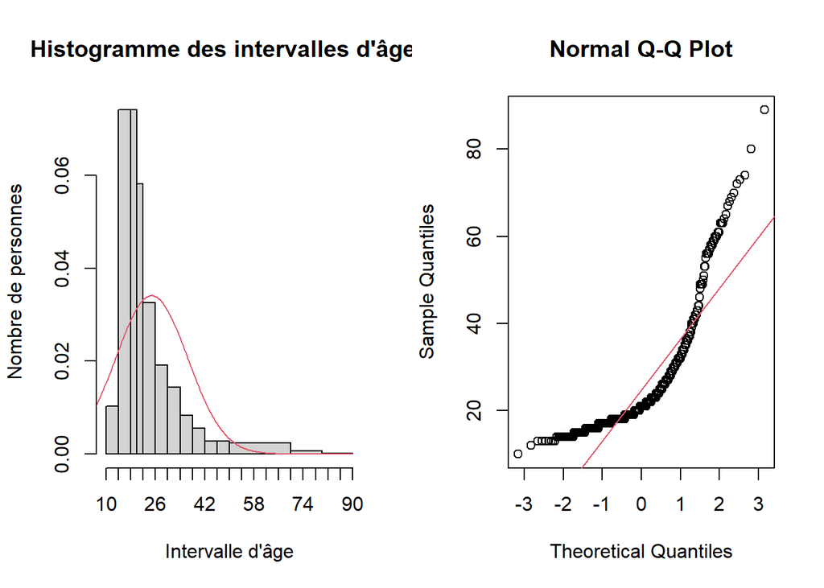

```r
qqnorm(resultat$Age)
abline(mean(resultat$Age),sd(resultat$Age),col=2)
```

```r
interval=t.test(resultat$Age, conf.level = 0.5)
interval$conf.int
```

```
## [1] 24.4463 25.0760
## attr(,"conf.level")
## [1] 0.5
```

- *Depression* : discrete

```r
depression_counts<- table(round(resultat$Depression))
#J'ai fait un round car y a deux personnes qui ont mis 3.5 et je l'ai ai compté avec 4
depression_counts_df <- as.data.frame(depression_counts)
print(depression_counts_df)
```

```
##    Var1 Freq
## 1     0   68
## 2     1   32
## 3     2   76
## 4     3   46
## 5     4   58
## 6     5   48
## 7     6   79
## 8     7   82
## 9     8   66
## 10    9   33
## 11   10   40
```

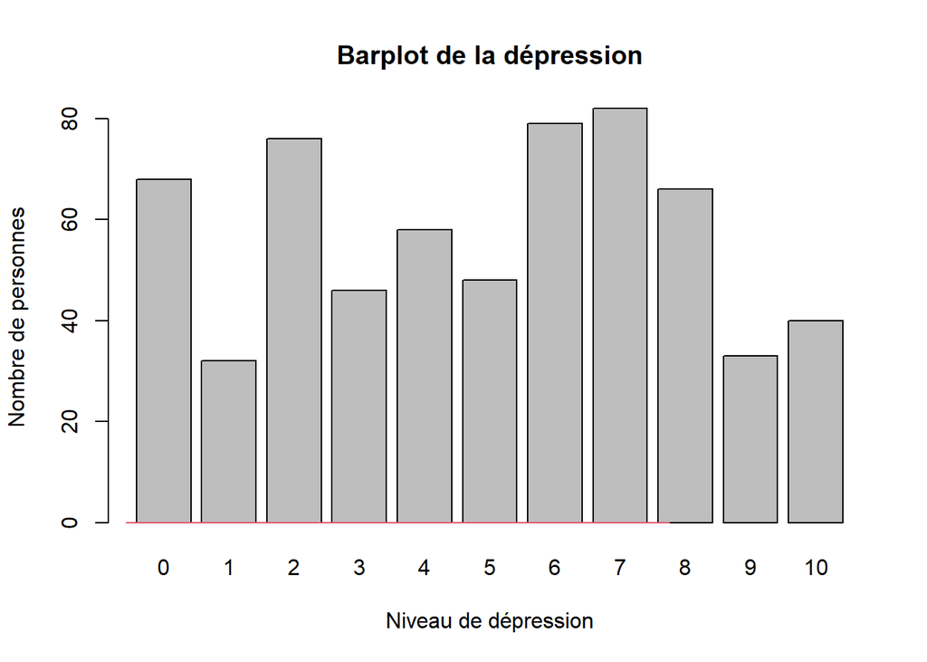

```r
# Renommer les colonnes du data frame
colnames(depression_counts_df) <- c("Niveau de dépression", "Nombre de personnes")

barplot(depression_counts_df$`Nombre de personnes`, names.arg = depression_counts_df$`Niveau de dépression`,
        xlab = "Niveau de dépression", ylab = "Nombre de personnes",
        main = "Barplot de la dépression")

points(seq(0,10,.5),dnorm(seq(0,10,0.5),mean(depression_counts_df$`Nombre de personnes`),sd(depression_counts_df$`Nombre de personnes`)),col=2,type="l")
```

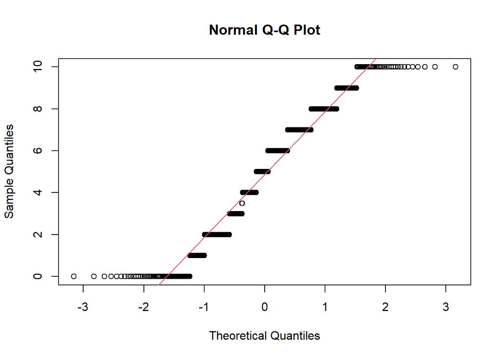

```r
#curve(dnorm(depression_counts_df$`Nombre de personnes`, mean(depression_counts_df$`Nombre de personnes`), sd(depression_counts_df$`Nombre de personnes`), col=2, add=TRUE, lty=2))
#print(resultat$Depression)
qqnorm(resultat$Depression)
abline(mean(resultat$Depression),sd(resultat$Depression),col=2)
```

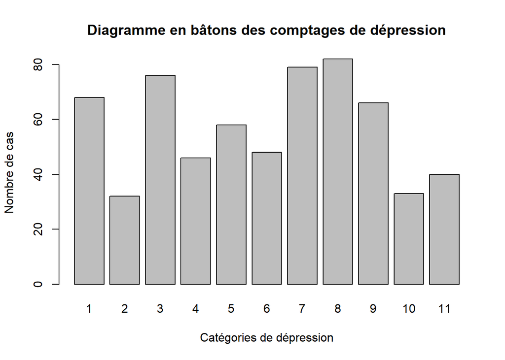

```r
# Créer le diagramme en bâtons
barplot(table(round(resultat$Depression)),
        names.arg = rownames(depression_counts_df),
        xlab = "Catégories de dépression",
        ylab = "Nombre de cas",
        main = "Diagramme en bâtons des comptages de dépression")
```

- *BPM* : discrète

[figure not shown]

```r
bpm_counts<-table(resultat$BPM)
bpm_counts_df<- as.data.frame(bpm_counts)
#Ici on supprime la dernière ligne car elle contient 999999 beats / minute ce qui est une valeur impossible
bpm_counts_df <- bpm_counts_df[1:(nrow(bpm_counts_df)-1), ]
# Créer le diagramme en bâtons
colnames(bpm_counts_df) <- c( "Nombre de beats", "Nombres de réponses")

# Créer le graphique à barres
bar_plot <- ggplot(data.frame(bpm_counts_df),
                   aes(x = bpm_counts_df$`Nombre de beats`, y = bpm_counts_df$`Nombres de réponses`)) +
  geom_bar(stat = "identity")+ theme(axis.text.x = element_text(angle = -90, vjust = 0.5, hjust=1))+

  labs(x = "La fréquence à laquelle la personne écoute de la musique Rock", y = "Nombre de réponses", title = "Graphe représentant la variance de la fréquence à laquelle les participants écoutent de la musique Rock"+
         scale_x_continuous(breaks = seq(0, 140, 10)))
#points(seq(0,140,0.5),dnorm(seq(0,140,0.5),mean(resultat$BPM),sd(resultat$BPM)),col=2,type="l")
print(bar_plot)
```

[figure not shown]

```r
bar_plot <- bar_plot +
  geom_line(data = data.frame(x = seq(0, 140, 0.5)),
            aes(x = x, y = dnorm(x, mean(resultat$BPM), sd(resultat$BPM))),
            col = "red")

print(bar_plot)
```

```r
moy <-mean(resultat$BPM) # moyenne de la population.
median(bpm_counts_df$`Nombres de réponses`)
```

```
## [1] 3
```

[figure not shown]

```r
std <- sd(resultat$BPM) # écart-type de la population
plot(function(x) dnorm(x,moy,std),main = "",lwd=3,xlab="Taille des pièces (en mm)",ylab="Fréquence")
```

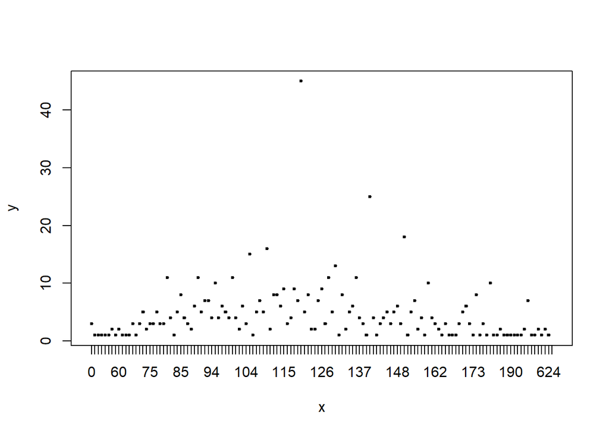

```r
plot(bpm_counts_df$`Nombre de beats`, bpm_counts_df$`Nombres de réponses`, type)
```

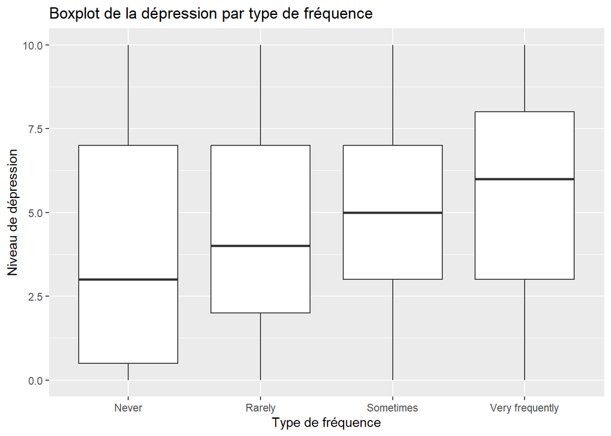

```r
ggplot(resultat, aes(x = resultat$Frequency..Rock., y = resultat$Depression)) +
  geom_boxplot() +
  labs(x = "Type de fréquence", y = "Niveau de dépression", title = "Boxplot de la dépression par type de fréquence")
```

Rapport de corrélation :

```r
#Moyenne au sein du groupe 1 : Never
moyenne1<- mean(resultat$Depression[resultat$Frequency..Rock.=='Never'])
moyenne2<- mean(resultat$Depression[resultat$Frequency..Rock.=='Very frequently'])
moyenne3<- mean(resultat$Depression[resultat$Frequency..Rock.=='Sometimes'])
moyenne4<- mean(resultat$Depression[resultat$Frequency..Rock.=='Rarely'])
####Variance de y dans chaque sous groupe
var1<- var(resultat$Depression[resultat$Frequency..Rock.=='Never'])
var2<- var(resultat$Depression[resultat$Frequency..Rock.=='Very frequently'])
var3<- var(resultat$Depression[resultat$Frequency..Rock.=='Sometimes'])
var4<- var(resultat$Depression[resultat$Frequency..Rock.=='Rarely'])


####
frequency_rock_counts<- table(resultat$Frequency..Rock.)
frequency_rock_counts_df <- as.data.frame(frequency_rock_counts)

moyennes<-c(moyenne1,moyenne4,moyenne3,moyenne2)
variances<-c(var1,var4,var3,var2)
frequency_rock_counts_df$Moyennes <- moyennes
frequency_rock_counts_df$`Variance dans chaque groupe` <- variances
colnames(frequency_rock_counts_df)<-c("Frequency","Nombre de reponses","Moyennes","Variance dans chaque groupe")
print(frequency_rock_counts_df) #pour avoir le nombre de réponses
```

```
##         Frequency Nombre de reponses Moyennes Variance dans chaque groupe
## 1           Never                 83 3.698795                    9.895974
## 2          Rarely                 79 4.164557                    8.677702
## 3       Sometimes                185 5.010811                    8.043361
## 4 Very frequently                281 5.348754                    8.826150
```

```r
#La moyenne globale c'est la moyenne pondérée des moyennes des groupes
# Calculer la moyenne pondérée
moyenne_ponderee <- sum(frequency_rock_counts_df$`Nombre de reponses` * frequency_rock_counts_df$Moyennes) /
                    sum(frequency_rock_counts_df$`Nombre de reponses`)
# Moyenne pondérée
print(sum(frequency_rock_counts_df$`Nombre de reponses` * frequency_rock_counts_df$Moyennes))
```

```
## [1] 3066
```

```r
print(moyenne_ponderee)
```

```
## [1] 4.882166
```

```r
#Var(Y) : Variance totale
variance<-var(resultat$Depression)
print(variance)
```

```
## [1] 9.028358
```

```r
#Variance interclasse (B)
B<- sum(frequency_rock_counts_df$`Nombre de reponses` *
          (frequency_rock_counts_df$Moyennes - moyenne_ponderee )^ 2)/sum(frequency_rock_counts_df$`Nombre de reponses`)
print(B)
```

```
## [1] 0.3521484
```

```r
#Variance intraclasse (W)
W<- sum(frequency_rock_counts_df$`Nombre de reponses` *
          (frequency_rock_counts_df $`Variance dans chaque groupe` ))/sum(frequency_rock_counts_df$`Nombre de reponses`)
print(W)
```

```
## [1] 8.718271
```

```r
#
```

```r
V<- B +W
print(V)
```

```
## [1] 9.070419
```

```r
rapport_correlation<- B/V
print(rapport_correlation)
```

```
## [1] 0.03882382
```

## Le rapport de corrélation est proche de 0 alors il semble ne pas avoir de lien entre les deux variables ; autrement dit, la fréquence de l’écoute de musique rock ne donne pas d’information sur le niveau de dépression des personnes.

quanti* quanti :

```r
# Créer des intervalles d'âges personnalisés
intervalles <- cut(resultat$Age, breaks = c(10, 14, 18,20, 22, 26, 30, 34, 38, 42, 46, 50, Inf), right = FALSE, include.lowest = TRUE)

tableau_intervalles <- table(intervalles)
age_df<- data.frame(tableau_intervalles)
print(age_df)
```

```
##    intervalles Freq
## 1      [10,14)    9
## 2      [14,18)  128
## 3      [18,20)  132
## 4      [20,22)   77
## 5      [22,26)   97
## 6      [26,30)   54
## 7      [30,34)   40
## 8      [34,38)   24
## 9      [38,42)   14
## 10     [42,46)   10
## 11     [46,50)    7
## 12    [50,Inf]   36
```

```r
colnames(age_df) <- c("Ages", "Nombre de personnes")
age_df$Ages <- factor(age_df$Ages, levels = unique(age_df$Ages))
print(age_df$Ages)
```

```
##  [1] [10,14)  [14,18)  [18,20)  [20,22)  [22,26)  [26,30)  [30,34)  [34,38)
##  [9] [38,42)  [42,46)  [46,50)  [50,Inf]
## 12 Levels: [10,14) [14,18) [18,20) [20,22) [22,26) [26,30) [30,34) ... [50,Inf]
```

```r
moyenne_bpm <- aggregate(resultat$BPM ~ intervalles, data = resultat, FUN = mean)
colnames(moyenne_bpm) <- c("Intervalles", "Moyenne BPM")
print(moyenne_bpm)
```

```
##    Intervalles  Moyenne BPM
## 1      [10,14)     116.1111
## 2      [14,18) 7812627.4531
## 3      [18,20)     120.1288
## 4      [20,22)     123.8701
## 5      [22,26)     119.8041
## 6      [26,30)     131.8519
## 7      [30,34)     124.3000
## 8      [34,38)     119.1250
## 9      [38,42)     132.5714
## 10     [42,46)     115.5000
## 11     [46,50)     131.1429
## 12    [50,Inf]     115.8056
```

```r
#cor(intervalles,moyenne_bpm$`Moyenne BPM`)
```

```r
#plot(resultat$Age, resultat$BPM,xlab = "Âge", ylab = "BPM",ylim = c(0, 180))
cor(resultat$Age, resultat$BPM)
```

```
## [1] -0.02995137
```

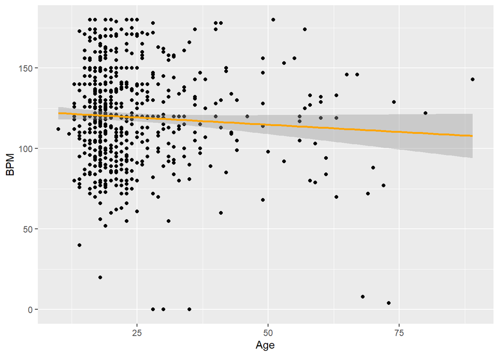

```r
table = data.frame(resultat$Age, resultat$BPM)
colnames(table)[1] <- "Age";
colnames(table)[2] <- "BPM";
ggplot(data = table, aes(x = Age, y = BPM)) +
  ylim(0, 180) +
  geom_point() +
  geom_smooth(method = "lm", color = "orange")
```

```r
#exploratory_plateform<- data.frame(resultat$Primary.streaming.service,resultat$Exploratory)
#tableau_contingence<- table(exploratory_plateform$resultat.Primary.streaming.service,exploratory_plateform$resultat.Exploratory)
#Tableau de contingence
#print(tableau_contingence)
#Représentation graphique
#colnames(df)<- c("Plateform", "Response", "Effectif")
#ggplot(df, aes(x =Plateform, y=Effectif, fill=Response))+
 # geom_bar(stat = "identity", position = "stack")+
  #labs(c="Plateforme de streaming de musique", y="Nombre de réponses", fill="Réponse")+
  #theme_minimal()

#Il faut commenter ça
```